# Comparing Groups: Tables and Visualizations

Session 1

Luis F. Gómez L.

luis.gomezl@unimilitar.edu.co

Distance Learning Faculty

15 September, 2026

# Please Read Me

- This presentation is based on (Chapman & Feit, 2019, Chapter 5)
- **Purpose**
  - Use descriptive summaries by groups and visualize them to investigate differences between groups

# Consumer segmentation survey

- **age**: age of the consumer in years
- **gender**: if the consumer is male of female
- **income**: yearly disposable income of the consumer
- **kids**: number of children of the consumer
- **ownHome**: if the consumer owns a home
- **subscribe**: if the consumer is subscribed or not
- **Segment**: market segment assigned by a clustering algorithm (Chapman & Feit, 2019, Chapter 11), expert assignment or a segmentation typing tool
- **Segment**:
  - **Moving up**: consumers experiencing upward mobility in terms of their socioeconomic status
  - **Suburb mix**: consumers living in suburban areas
  - **Travelers**: consumers who prioritize experiences and adventures
  - **Urban Hip**: consumers interested in urban culture, artistic expression, and modern trends

```r
segmentation <- read_csv(
  file = "http://goo.gl/qw303p"
)

segmentation |>
  head(n = 5)
```

```
# A tibble: 5 × 7
    age gender income  kids ownHome subscribe Segment
  <dbl> <chr>   <dbl> <dbl> <chr>   <chr>     <chr>
1  47.3 Male   49483.     2 ownNo   subNo     Suburb mix
2  31.4 Male   35546.     1 ownYes  subNo     Suburb mix
3  43.2 Male   44169.     0 ownYes  subNo     Suburb mix
4  37.3 Female 81042.     1 ownNo   subNo     Suburb mix
5  41.0 Female 79353.     3 ownYes  subNo     Suburb mix
```

- **Import data**

```r
segmentation <- segmentation |>
  mutate(
    gender = factor(gender, ordered = FALSE),
    kids = as.integer(kids),
    ownHome = factor(ownHome, ordered = FALSE),
    subscribe = factor(subscribe, ordered = FALSE),
    Segment = factor(Segment, ordered = FALSE)
  )

segmentation |>
  head(n = 5)
```

```
# A tibble: 5 × 7
    age gender income  kids ownHome subscribe Segment
  <dbl> <fct>   <dbl> <int> <fct>   <fct>     <fct>
1  47.3 Male   49483.     2 ownNo   subNo     Suburb mix
2  31.4 Male   35546.     1 ownYes  subNo     Suburb mix
3  43.2 Male   44169.     0 ownYes  subNo     Suburb mix
4  37.3 Female 81042.     1 ownNo   subNo     Suburb mix
5  41.0 Female 79353.     3 ownYes  subNo     Suburb mix
```

- **Transform data**

```r
?`+` # Arithmetic Operators

?formula # operators in a formula
```

- **Basic Formula Syntax**
  - $\sim$ and $+$: operators
  - $y$: response variable
  - $x, z$: explanatory variables
  - $y \sim x + z$: a formula which means that $y$ depends on $x$ and $z$
    - $+$ is used to indicate the addition of predictor variables to the right of the formula
    - Be careful not to confuse the arithmetic operator $+$ with $+$ within a formula

```r
segmentation |>
  group_by(Segment, ownHome) |>
  summarise(mean_income = mean(income))
```

```
# A tibble: 8 × 3
# Groups:   Segment [4]
  Segment    ownHome mean_income
  <fct>      <fct>         <dbl>
1 Moving up  ownNo        54498.
2 Moving up  ownYes       50216.
3 Suburb mix ownNo        54933.
4 Suburb mix ownYes       55143.
5 Travelers  ownNo        63188.
6 Travelers  ownYes       61889.
7 Urban hip  ownNo        21338.
8 Urban hip  ownYes       23059.
```

- **Descriptives for n-Way Groups**
  - the tidyverse way
    - Split data into $n$ subsets
    - Compute summary statistics

```r
segmentation |>
  group_by(Segment, ownHome) |>
  summarise(sum_kids = sum(kids))
```

```
# A tibble: 8 × 3
# Groups:   Segment [4]
  Segment    ownHome sum_kids
  <fct>      <fct>      <int>
1 Moving up  ownNo         82
2 Moving up  ownYes        52
3 Suburb mix ownNo         90
4 Suburb mix ownYes       102
5 Travelers  ownNo          0
6 Travelers  ownYes         0
7 Urban hip  ownNo         43
8 Urban hip  ownYes        12
```

- **Descriptives for n-Way Groups**
  - the tidyverse way
    - Split data into $n$ subsets
    - Compute summary statistics

```r
?`|` # Logical Operators

?lattice::xyplot # operators in a formula
# -------------- # you need first to install
# -------------- # the package lattice
```

- **Basic Formula Syntax**
  - $\sim$, $+$ and $|$: operators
  - $y$: response variable
  - $x$: explanatory variable
  - $z$: grouping variable
  - $y \sim x | z$: $y$ depends on $x$ based on different groups defined by $z$
    - $|$ is used to separate the grouping variable from the explanatory variable
    - Be careful not to confuse the logical operator $|$ with $|$ within a formula

```r
# Prepare data
subscriber_by_segment_home_ownership <- segmentation |>
  count(subscribe, Segment, ownHome) |>
  group_by(Segment, ownHome) |>
  mutate(n_pct = (n / sum(n)) * 100) |>
  ungroup() |>
  arrange(Segment, ownHome)

subscriber_by_segment_home_ownership
```

```
# A tibble: 16 × 5
   subscribe Segment    ownHome     n n_pct
   <fct>     <fct>      <fct>   <int> <dbl>
 1 subNo     Moving up  ownNo      38 80.9
 2 subYes    Moving up  ownNo       9 19.1
 3 subNo     Moving up  ownYes     18 78.3
 4 subYes    Moving up  ownYes      5 21.7
 5 subNo     Suburb mix ownNo      50 96.2
 6 subYes    Suburb mix ownNo       2  3.85
 7 subNo     Suburb mix ownYes     44 91.7
 8 subYes    Suburb mix ownYes      4  8.33
 9 subNo     Travelers  ownNo      17 85
10 subYes    Travelers  ownNo       3 15
11 subNo     Travelers  ownYes     53 88.3
12 subYes    Travelers  ownYes      7 11.7
13 subNo     Urban hip  ownNo      32 80
14 subYes    Urban hip  ownNo       8 20
15 subNo     Urban hip  ownYes      8 80
16 subYes    Urban hip  ownYes      2 20
```

- **Visualization by group as frequencies**
  - the tidyverse way
- **Visualization by group as frequencies**
  - the tidyverse way

```r
subscriber_by_segment_home_ownership |>
  ggplot() +
  geom_col(aes(x = subscribe, y = n_pct)) +
  facet_wrap(
    facets = vars(Segment, ownHome),
    nrow = 2,
    ncol = 4
  )
```

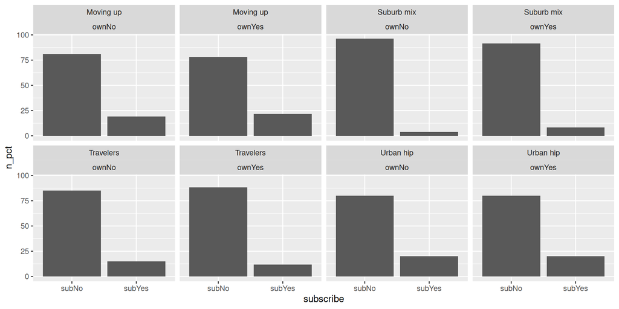

Figure 1: Visualization by group as frequencies using `facet_wrap()`

- **Visualization by group as proportions**
  - the tidyverse way

```r
# Prepare data
prop_table <- segmentation |>
  count(subscribe, Segment) |>
  group_by(Segment) |>
  mutate(n_pct = n / sum(n)) |>
  filter(subscribe == "subYes")
```

```r
prop_table |>
  ggplot() +
  geom_col(
    aes(x = n_pct, y = Segment),
    fill = "darkolivegreen"
  ) +
  labs(
    x = "Subscriber proportion by Segment",
    y = NULL
  )
```

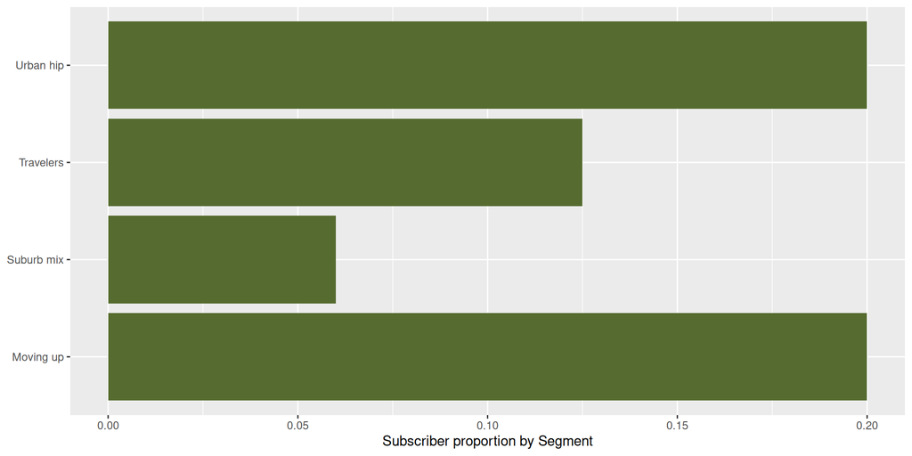

Figure 2: Visualization of subscriber proportions by segment

- **Visualization by group with continuous data**
  - the tidyverse way

```r
# Prepare data
seg_income_agg <- segmentation |>
  group_by(Segment, ownHome) |>
  summarise(mean_income = mean(income)) |>
  ungroup()
```

```r
seg_income_agg |>
  ggplot() +
  geom_col(
    aes(x = Segment, y = mean_income, fill = ownHome),
    position = position_dodge(),
    color = "black"
  ) +
  scale_fill_manual(values = terrain.colors(n = 2))
```

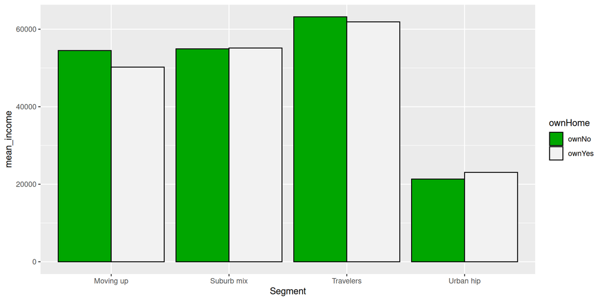

Figure 3: Mean income by segment and home ownership

- **Visualization by group with continuous data**
  - the tidyverse way

```r
segmentation |>
  ggplot() +
  geom_boxplot(aes(x = income, y = Segment)) +
  facet_wrap(facets = vars(ownHome)) +
  labs(x = "Income", y = NULL)
```

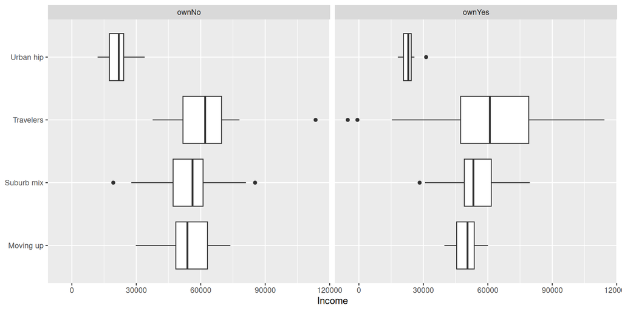

Figure 4: Income distribution by segment faceted by home ownership

# Acknowledgments

- To my family that supports me
- To the taxpayers of Colombia and the [**UMNG students**](https://www.umng.edu.co/estudiante) who pay my salary
- To the [**Business Science**](https://www.business-science.io/) and [**R4DS Online Learning**](https://www.rfordatasci.com/) communities where I learn [**R**](https://www.r-project.org/about.html) and [**$\pi$-thon**](https://www.python.org/about/)
- To the [**R Core Team**](https://www.r-project.org/contributors.html), the creators of [**RStudio IDE**](https://posit.co/products/open-source/rstudio/), [**Quarto**](https://quarto.org/) and the authors and maintainers of the packages [**tidyverse**](https://CRAN.R-project.org/package=tidyverse), [**lattice**](https://CRAN.R-project.org/package=lattice) and [**tinytex**](https://CRAN.R-project.org/package=tinytex) for allowing me to access these tools without paying for a license

# References

Chapman, C., & Feit, E. M. (2019). *R For Marketing Research and Analytics* (2nd ed. 2019). Springer International Publishing : Imprint: Springer. https://doi-org.ezproxy.umng.edu.co/10.1007/978-3-030-14316-9